# Tutorial 5 - Soccer

Zachary Binney, PhD

October 2023

```r
pacman::p_load(tidyverse)
```

# Introduction to `StatsBombR`

The bulk of this tutorial lab will be focused on learning to use the `StatsBombR` package, which offers free but rich events data on a selection of soccer matches from the company StatsBomb, including data from Messi’s entire career as well the National Women’s Soccer League, the FA Women’s Super League, and the two most recent Women’s and Men’s World Cups.

It’s far from the only source of soccer data out there, but it’s the one with perhaps the most well-developed interface for using it in R.

We’ll be working from a few different resources on `StatsBombR`, but the main one is StatsBomb’s own [“Accessing and Working With StatsBomb Data in R”](https://statsbomb.com/wp-content/uploads/2022/08/Working-with-R.pdf), which we’ll refer to as the the “StatsBomb Guide” below.

## StatsBomb 360 Data

In addition to regular event data, StatsBomb has released samples of its enhanced “StatsBomb 360” data for the most recent World Cups (2022 men’s, 2023 women’s) as well as the Men’s EURO 2020 and Women’s EURO 2022. We will just be working with the regular events data to avoid the added complexity of the 360 data.

With that complexity, however, comes richness. If you are interested in soccer analytics I strongly encourage you to work through the [StatsBomb 360 Data Case Study from the Men’s EURO 2020](https://statsbomb.com/news/statsbomb-announce-the-release-of-free-statsbomb-360-data-euro-2020-available-now/).

## Installing `StatsBombR` and Exploring the Data

Let’s go to page 8 of the StatsBomb Guide to learn how to install the package. It’s a bit complicated. We’ll also install a couple helper packages, `soccermatics` and `SBpitch`, that have some built-in functions to more easily analyze StatsBomb data in R.

```r
# pacman::p_load(devtools, remotes)
#
# remotes::install_version("SDMTools", "1.1-221")
#
# devtools::install_github("statsbomb/StatsBombR")
#
# devtools::install_github("jogall/soccermatics")
#
# devtools::install_github("FCrSTATS/SBpitch")


pacman::p_load(StatsBombR, soccermatics, SBpitch, ggrepel, ggtext, glue, knitr)
```

Now let’s start exploring the data, starting on page 11 of the StatsBomb Guide.

Let’s start by getting a list of the “competitions” the package offers for free:

```r
# Pull and print list of competitions available
comps <- FreeCompetitions()
```

```
## [1] "Whilst we are keen to share data and facilitate research, we also urge you to be responsible with the data. Please credit StatsBomb as your data source when using the data and visit https://statsbomb.com/media-pack/ to obtain our logos for public use."
```

```r
kable(as.tibble(comps))
```

| competition_id | season_id | country_name | competition_name | competition_gender | competition_youth | competition_international | season_name | match_updated | match_updated_360 | match_available_360 | match_available |
| --- | --- | --- | --- | --- | --- | --- | --- | --- | --- | --- | --- |
| 9 | 27 | Germany | 1. Bundesliga | male | FALSE | FALSE | 2015/2016 | 2023-08-17T23:51:11.837478 | NA | NA | 2023-08-17T23:51:11.837478 |
| 16 | 4 | Europe | Champions League | male | FALSE | FALSE | 2018/2019 | 2023-03-07T12:20:48.118250 | 2021-06-13T16:17:31.694 | NA | 2023-03-07T12:20:48.118250 |
| 16 | 1 | Europe | Champions League | male | FALSE | FALSE | 2017/2018 | 2021-08-27T11:26:39.802832 | 2021-06-13T16:17:31.694 | NA | 2021-01-23T21:55:30.425330 |
| 16 | 2 | Europe | Champions League | male | FALSE | FALSE | 2016/2017 | 2021-08-27T11:26:39.802832 | 2021-06-13T16:17:31.694 | NA | 2020-07-29T05:00 |
| 16 | 27 | Europe | Champions League | male | FALSE | FALSE | 2015/2016 | 2021-08-27T11:26:39.802832 | 2021-06-13T16:17:31.694 | NA | 2020-07-29T05:00 |
| 16 | 26 | Europe | Champions League | male | FALSE | FALSE | 2014/2015 | 2021-08-27T11:26:39.802832 | 2021-06-13T16:17:31.694 | NA | 2020-07-29T05:00 |
| 16 | 25 | Europe | Champions League | male | FALSE | FALSE | 2013/2014 | 2021-08-27T11:26:39.802832 | 2021-06-13T16:17:31.694 | NA | 2020-07-29T05:00 |
| 16 | 24 | Europe | Champions League | male | FALSE | FALSE | 2012/2013 | 2021-08-27T11:26:39.802832 | 2021-06-13T16:17:31.694 | NA | 2021-07-10T13:41:45.751 |
| 16 | 23 | Europe | Champions League | male | FALSE | FALSE | 2011/2012 | 2021-08-27T11:26:39.802832 | 2021-06-13T16:17:31.694 | NA | 2020-07-29T05:00 |
| 16 | 22 | Europe | Champions League | male | FALSE | FALSE | 2010/2011 | 2022-01-26T21:07:11.033473 | 2021-06-13T16:17:31.694 | NA | 2022-01-26T21:07:11.033473 |
| 16 | 21 | Europe | Champions League | male | FALSE | FALSE | 2009/2010 | 2022-11-15T17:26:10.871011 | 2021-06-13T16:17:31.694 | NA | 2022-11-15T17:26:10.871011 |
| 16 | 41 | Europe | Champions League | male | FALSE | FALSE | 2008/2009 | 2021-11-07T14:20:01.699993 | 2021-06-13T16:17:31.694 | NA | 2021-11-07T14:20:01.699993 |
| 16 | 39 | Europe | Champions League | male | FALSE | FALSE | 2006/2007 | 2021-03-31T04:18:30.437060 | 2021-06-13T16:17:31.694 | NA | 2021-03-31T04:18:30.437060 |
| 16 | 37 | Europe | Champions League | male | FALSE | FALSE | 2004/2005 | 2021-04-01T06:18:57.459032 | 2021-06-13T16:17:31.694 | NA | 2021-04-01T06:18:57.459032 |
| 16 | 44 | Europe | Champions League | male | FALSE | FALSE | 2003/2004 | 2022-11-24T21:06:10.454916 | 2021-06-13T16:17:31.694 | NA | 2022-11-24T21:06:10.454916 |
| 16 | 76 | Europe | Champions League | male | FALSE | FALSE | 1999/2000 | 2020-07-29T05:00 | 2021-06-13T16:17:31.694 | NA | 2020-07-29T05:00 |
| 16 | 277 | Europe | Champions League | male | FALSE | FALSE | 1972/1973 | 2023-07-06T12:49:07.467625 | NA | NA | 2023-07-06T12:49:07.467625 |
| 16 | 71 | Europe | Champions League | male | FALSE | FALSE | 1971/1972 | 2020-07-29T05:00 | 2021-06-13T16:17:31.694 | NA | 2020-07-29T05:00 |
| 16 | 276 | Europe | Champions League | male | FALSE | FALSE | 1970/1971 | 2023-07-06T12:50:01.961048 | NA | NA | 2023-07-06T12:50:01.961048 |
| 87 | 84 | Spain | Copa del Rey | male | FALSE | FALSE | 1983/1984 | 2020-07-29T05:00 | 2021-06-13T16:17:31.694 | NA | 2020-07-29T05:00 |
| 87 | 268 | Spain | Copa del Rey | male | FALSE | FALSE | 1982/1983 | 2023-06-11T02:51:59.941964 | NA | NA | 2023-06-11T02:51:59.941964 |
| 87 | 279 | Spain | Copa del Rey | male | FALSE | FALSE | 1977/1978 | 2023-06-26T10:36:15.442581 | NA | NA | 2023-06-26T10:36:15.442581 |
| 37 | 90 | England | FA Women’s Super League | female | FALSE | FALSE | 2020/2021 | 2023-02-25T14:52:09.326729 | 2021-06-13T16:17:31.694 | NA | 2023-02-25T14:52:09.326729 |
| 37 | 42 | England | FA Women’s Super League | female | FALSE | FALSE | 2019/2020 | 2023-07-25T01:08:03.214566 | 2021-06-13T16:17:31.694 | NA | 2023-07-25T01:08:03.214566 |
| 37 | 4 | England | FA Women’s Super League | female | FALSE | FALSE | 2018/2019 | 2023-07-24T19:50:20.881595 | 2021-06-13T16:17:31.694 | NA | 2023-07-24T19:50:20.881595 |
| 1470 | 274 | International | FIFA U20 World Cup | male | FALSE | FALSE | 1979 | 2023-06-28T10:55:11.501179 | NA | NA | 2023-06-28T10:55:11.501179 |
| 43 | 106 | International | FIFA World Cup | male | FALSE | TRUE | 2022 | 2023-08-12T16:44:27.619465 | 2023-08-17T15:55:15.164685 | 2023-08-17T15:55:15.164685 | 2023-08-12T16:44:27.619465 |
| 43 | 3 | International | FIFA World Cup | male | FALSE | TRUE | 2018 | 2023-07-24T13:09:34.513519 | 2021-06-13T16:17:31.694 | NA | 2023-07-24T13:09:34.513519 |
| 43 | 55 | International | FIFA World Cup | male | FALSE | TRUE | 1990 | 2023-06-28T10:58:20.137929 | 2021-06-12T16:17:31.694 | NA | 2023-06-28T10:58:20.137929 |
| 43 | 54 | International | FIFA World Cup | male | FALSE | TRUE | 1986 | 2023-06-28T11:20:34.252935 | 2021-06-13T16:17:31.694 | NA | 2023-06-28T11:20:34.252935 |
| 43 | 51 | International | FIFA World Cup | male | FALSE | TRUE | 1974 | 2023-07-17T23:19:58.853207 | 2021-06-13T16:17:31.694 | NA | 2023-07-17T23:19:58.853207 |
| 43 | 272 | International | FIFA World Cup | male | FALSE | TRUE | 1970 | 2023-07-17T23:24:45.579886 | NA | NA | 2023-07-17T23:24:45.579886 |
| 43 | 270 | International | FIFA World Cup | male | FALSE | TRUE | 1962 | 2023-06-26T10:38:00.323984 | NA | NA | 2023-06-26T10:38:00.323984 |
| 43 | 269 | International | FIFA World Cup | male | FALSE | TRUE | 1958 | 2023-06-26T10:33:08.214831 | NA | NA | 2023-06-26T10:33:08.214831 |
| 1238 | 108 | India | Indian Super league | male | FALSE | FALSE | 2021/2022 | 2023-03-31T02:14:09.896947 | NA | NA | 2023-03-31T02:14:09.896947 |
| 11 | 90 | Spain | La Liga | male | FALSE | FALSE | 2020/2021 | 2023-07-26T14:11:01.312143 | 2023-07-26T14:15:15.217027 | 2023-07-26T14:15:15.217027 | 2023-07-26T14:11:01.312143 |
| 11 | 42 | Spain | La Liga | male | FALSE | FALSE | 2019/2020 | 2023-07-25T00:16:32.999467 | 2021-06-13T16:17:31.694 | NA | 2023-07-25T00:16:32.999467 |
| 11 | 4 | Spain | La Liga | male | FALSE | FALSE | 2018/2019 | 2023-08-03T02:24:43.761907 | 2021-07-09T14:53:22.103024 | NA | 2023-08-03T02:24:43.761907 |
| 11 | 1 | Spain | La Liga | male | FALSE | FALSE | 2017/2018 | 2023-07-24T13:03:48.574627 | 2021-06-13T16:17:31.694 | NA | 2023-07-24T13:03:48.574627 |
| 11 | 2 | Spain | La Liga | male | FALSE | FALSE | 2016/2017 | 2023-07-25T00:14:55.260536 | 2021-06-13T16:17:31.694 | NA | 2023-07-25T00:14:55.260536 |
| 11 | 27 | Spain | La Liga | male | FALSE | FALSE | 2015/2016 | 2023-07-24T21:52:42.890908 | 2021-06-13T16:17:31.694 | NA | 2023-07-24T21:52:42.890908 |
| 11 | 26 | Spain | La Liga | male | FALSE | FALSE | 2014/2015 | 2023-07-24T21:50:15.215072 | 2021-06-13T16:17:31.694 | NA | 2023-07-24T21:50:15.215072 |
| 11 | 25 | Spain | La Liga | male | FALSE | FALSE | 2013/2014 | 2022-07-23T12:18:49.547396 | 2021-06-13T16:17:31.694 | NA | 2022-07-23T12:18:49.547396 |
| 11 | 24 | Spain | La Liga | male | FALSE | FALSE | 2012/2013 | 2022-09-25T20:52:24.444609 | 2021-06-13T16:17:31.694 | NA | 2022-09-25T20:52:24.444609 |
| 11 | 23 | Spain | La Liga | male | FALSE | FALSE | 2011/2012 | 2022-12-01T14:10:17.791769 | 2021-06-13T16:17:31.694 | NA | 2022-12-01T14:10:17.791769 |
| 11 | 22 | Spain | La Liga | male | FALSE | FALSE | 2010/2011 | 2023-04-19T10:48:44.079830 | 2021-06-13T16:17:31.694 | NA | 2023-04-19T10:48:44.079830 |
| 11 | 21 | Spain | La Liga | male | FALSE | FALSE | 2009/2010 | 2023-04-19T10:48:01.770383 | 2021-06-13T16:17:31.694 | NA | 2023-04-19T10:48:01.770383 |
| 11 | 41 | Spain | La Liga | male | FALSE | FALSE | 2008/2009 | 2023-04-19T10:46:29.203565 | 2021-06-13T16:17:31.694 | NA | 2023-04-19T10:46:29.203565 |
| 11 | 40 | Spain | La Liga | male | FALSE | FALSE | 2007/2008 | 2023-04-19T10:42:35.284291 | 2021-06-13T16:17:31.694 | NA | 2023-04-19T10:42:35.284291 |
| 11 | 39 | Spain | La Liga | male | FALSE | FALSE | 2006/2007 | 2023-03-26T23:19:39.125951 | 2021-06-13T16:17:31.694 | NA | 2023-03-26T23:19:39.125951 |
| 11 | 38 | Spain | La Liga | male | FALSE | FALSE | 2005/2006 | 2022-07-03T12:34:31.749038 | 2021-06-13T16:17:31.694 | NA | 2022-07-03T12:34:31.749038 |
| 11 | 37 | Spain | La Liga | male | FALSE | FALSE | 2004/2005 | 2020-07-29T05:00 | 2021-06-13T16:17:31.694 | NA | 2020-07-29T05:00 |
| 11 | 278 | Spain | La Liga | male | FALSE | FALSE | 1973/1974 | 2023-07-06T12:50:48.807820 | NA | NA | 2023-07-06T12:50:48.807820 |
| 81 | 48 | Argentina | Liga Profesional | male | FALSE | FALSE | 1997/1998 | 2023-06-28T11:19:54.593488 | NA | NA | 2023-06-28T11:19:54.593488 |
| 81 | 275 | Argentina | Liga Profesional | male | FALSE | FALSE | 1981 | 2023-06-28T11:31:57.152298 | NA | NA | 2023-06-28T11:31:57.152298 |
| 7 | 27 | France | Ligue 1 | male | FALSE | FALSE | 2015/2016 | 2023-08-31T19:38:46.331149 | NA | NA | 2023-08-31T19:38:46.331149 |
| 116 | 68 | North and Central America | North American League | male | FALSE | FALSE | 1977 | 2023-07-24T09:06:54.144896 | 2021-06-13T16:17:31.694 | NA | 2023-07-24T09:06:54.144896 |
| 49 | 3 | United States of America | NWSL | female | FALSE | FALSE | 2018 | 2023-07-24T13:01:22.094587 | 2021-06-13T16:17:31.694 | NA | 2023-07-24T13:01:22.094587 |
| 2 | 27 | England | Premier League | male | FALSE | FALSE | 2015/2016 | 2023-07-12T13:59:45.191483 | 2021-06-13T16:17:31.694 | NA | 2023-07-12T13:59:45.191483 |
| 2 | 44 | England | Premier League | male | FALSE | FALSE | 2003/2004 | 2023-03-11T10:52:12.579230 | 2021-06-13T16:17:31.694 | NA | 2023-03-11T10:52:12.579230 |
| 12 | 27 | Italy | Serie A | male | FALSE | FALSE | 2015/2016 | 2023-08-31T16:46:34.290341 | NA | NA | 2023-08-31T16:46:34.290341 |
| 12 | 86 | Italy | Serie A | male | FALSE | FALSE | 1986/1987 | 2023-06-18T01:55:53.343752 | NA | NA | 2023-06-18T01:55:53.343752 |
| 55 | 43 | Europe | UEFA Euro | male | FALSE | TRUE | 2020 | 2023-02-24T21:26:47.128979 | 2023-04-27T22:38:34.970148 | 2023-04-27T22:38:34.970148 | 2023-02-24T21:26:47.128979 |
| 35 | 75 | Europe | UEFA Europa League | male | FALSE | FALSE | 1988/1989 | 2023-06-18T19:28:39.443883 | 2021-06-13T16:17:31.694 | NA | 2023-06-18T19:28:39.443883 |
| 53 | 106 | Europe | UEFA Women’s Euro | female | FALSE | TRUE | 2022 | 2023-07-17T21:19:03.032991 | 2023-07-17T21:21:56.497106 | 2023-07-17T21:21:56.497106 | 2023-07-17T21:19:03.032991 |
| 72 | 107 | International | Women’s World Cup | female | FALSE | TRUE | 2023 | 2023-09-01T12:34:19.705316 | 2023-09-01T12:35:45.762196 | 2023-09-01T12:35:45.762196 | 2023-09-01T12:34:19.705316 |
| 72 | 30 | International | Women’s World Cup | female | FALSE | TRUE | 2019 | 2023-07-27T10:33:48.273734 | 2021-06-13T16:17:31.694 | NA | 2023-07-27T10:33:48.273734 |

**Lab Activity 1**: Take a look at the data and see if you can puzzle out what it might show. Use this list of free data releases to cross-reference what you see in the data with this full list of data releases (excluding matches from before 2000):

- FA Women’s Super League (18/19, 19/20, 20/21)
- The Lionel Messi Data Biography (04/05 – 20/21, various leagues)
- Arsenal Invincibles Season (03/04)
- UEFA Men’s Champions League Finals (various, 99/00 – 18/19)
- FIFA Men’s 2018 and 2022 World Cups - 2022 contains StatsBomb 360 data
- FIFA Women’s 2019 and 2023 World Cups - 2023 contains StatsBomb 360 data
- NWSL 2018 Season
- UEFA Euro 2020 (men’s) - StatsBomb 360 data
- UEFA Women’s Euro 2022 - StatsBomb 360 data
- Big 5 Leagues 2015/16 Seasons
- Indian Super League 2021/22 Season

Now let’s dive into the data available for one of the competitions - the 2023 Women’s World Cup. Let’s pull the list of available matches:

```r
# Pull match data for one competition
matches <- comps %>%
  filter(competition_name == "Women's World Cup", season_name == 2023) %>%
  FreeMatches()
```

```
## [1] "Whilst we are keen to share data and facilitate research, we also urge you to be responsible with the data. Please credit StatsBomb as your data source when using the data and visit https://statsbomb.com/media-pack/ to obtain our logos for public use."
```

```r
# Print
matches
```

```
## # A tibble: 64 x 42
##    match_id match_date kick_off  home_~1 away_~2 match~3 match~4 last_~5 last_~6
##       <int> <chr>      <chr>       <int>   <int> <chr>   <chr>   <chr>   <chr>
##  1  3904629 2023-08-16 13:00:00~       1       3 availa~ availa~ 2023-0~ 2023-0~
##  2  3906390 2023-08-20 13:00:00~       1       0 availa~ availa~ 2023-0~ 2023-0~
##  3  3906389 2023-08-19 11:00:00~       2       0 availa~ availa~ 2023-0~ 2023-0~
##  4  3904628 2023-08-15 11:00:00~       2       1 availa~ availa~ 2023-0~ 2023-0~
##  5  3893806 2023-07-26 10:30:00~       5       0 availa~ availa~ 2023-0~ 2023-0~
##  6  3893801 2023-07-24 14:00:00~       4       0 availa~ availa~ 2023-0~ 2023-0~
##  7  3893797 2023-07-23 10:30:00~       1       0 availa~ availa~ 2023-0~ 2023-0~
##  8  3893822 2023-07-31 10:00:00~       4       0 availa~ availa~ 2023-0~ 2023-0~
##  9  3893814 2023-07-29 10:30:00~       5       0 availa~ availa~ 2023-0~ 2023-0~
## 10  3893790 2023-07-21 05:30:00~       0       0 availa~ availa~ 2023-0~ 2023-0~
## # ... with 54 more rows, 33 more variables: match_week <int>,
## #   competition.competition_id <int>, competition.country_name <chr>,
## #   competition.competition_name <chr>, season.season_id <int>,
## #   season.season_name <chr>, home_team.home_team_id <int>,
## #   home_team.home_team_name <chr>, home_team.home_team_gender <chr>,
## #   home_team.home_team_group <lgl>, home_team.managers <list>,
## #   home_team.country.id <int>, home_team.country.name <chr>, ...
```

**Lab Activity 2**:

1. How many matches were there from that tournament? How many *should* there be?
2. What does each row of the data frame contain?
3. What are some of the main data points contained in each row? Explore the data using some of the techniques you’ve learned in the course so far.

Finally let’s dive down one more level and look at the data for a single match.

```r
# Pull events data for one match - specifically, the U.S. versus Netherlands group stage match
events <- StatsBombFreeEvents(MatchesDF = matches %>% filter(away_team.country.name == "Netherlands",
                                                             home_team.country.name == "United States of America")) %>%
  # Automatically do some data cleaning for better use in R
  allclean()
```

```
## [1] "Whilst we are keen to share data and facilitate research, we also urge you to be responsible with the data. Please credit StatsBomb as your data source when using the data and visit https://statsbomb.com/media-pack/ to obtain our logos for public use."
```

```r
# Print
events
```

```
## # A tibble: 3,719 x 158
##    id         index period times~1 minute second posse~2 durat~3 relat~4 locat~5
##    <chr>      <int>  <int> <chr>    <int>  <int>   <int>   <dbl> <list>  <list>
##  1 2c79414c-~     1      1 00:00:~      0      0       1    0    <NULL>  <NULL>
##  2 64b30c6c-~     2      1 00:00:~      0      0       1    0    <NULL>  <NULL>
##  3 0d06fee4-~     3      1 00:00:~      0      0       1    0    <chr>   <NULL>
##  4 2446a640-~     4      1 00:00:~      0      0       1    0    <chr>   <NULL>
##  5 5b66af23-~     5      1 00:00:~      0      0       2    1.23 <chr>   <dbl>
##  6 89b7c8fc-~     6      1 00:00:~      0      1       2   NA    <chr>   <dbl>
##  7 10272acd-~     7      1 00:00:~      0      1       2    1.10 <chr>   <dbl>
##  8 340cb075-~     8      1 00:00:~      0      2       2    5.84 <chr>   <dbl>
##  9 fdd953fb-~     9      1 00:00:~      0      8       3    0    <chr>   <dbl>
## 10 b9a4c492-~    10      1 00:00:~      0      8       3    8.81 <chr>   <dbl>
## # ... with 3,709 more rows, 148 more variables: under_pressure <lgl>,
## #   out <lgl>, counterpress <lgl>, off_camera <lgl>, type.id <int>,
## #   type.name <chr>, possession_team.id <int>, possession_team.name <chr>,
## #   play_pattern.id <int>, play_pattern.name <chr>, team.id <int>,
## #   team.name <chr>, tactics.formation <int>, tactics.lineup <list>,
## #   player.id <int>, player.name <chr>, position.id <int>, position.name <chr>,
## #   pass.length <dbl>, pass.angle <dbl>, pass.end_location <list>, ...
```

**Lab Activity 3**:

1. How many events were logged in this match?
2. What are the 3 most common types of events?
3. What are some of the main data points contained in each row? Explore the data using some of the techniques you’ve learned in the course so far.

For much more information on the data contained at each of these levels, see the links on page 14 of the StatsBomb Guide.

### StatsBomb Data Dictionary

To help orient you to the data further, please keep the StatsBomb “data specification” (what I would call a data dictionary) nearby. It lists every variable in all their various datasets and an explanation of what each contains. [Here’s a link](https://github.com/statsbomb/open-data/blob/master/doc/StatsBomb%20Open%20Data%20Specification%20v1.1.pdf).

## Data Use Cases

Now let’s get into just a few fun things we can do with the data.

### xG Plots

Let’s start with some xG plots. Specifically, let’s start by mapping the xG of the shots from the game above.

#### xG Map

This xG plot code is part of the [`soccermetrics` package from Joe Gallagher](https://github.com/JoGall/soccermatics). Be aware this package is under active development and may change with little notice. Indeed, some of the code offered at that link doesn’t appear to match up to what the package is actually capable of. I’m still including it because of its relative simplicity for performing certain tasks.

Here, for example, is code to produce a shot map for the U.S.:

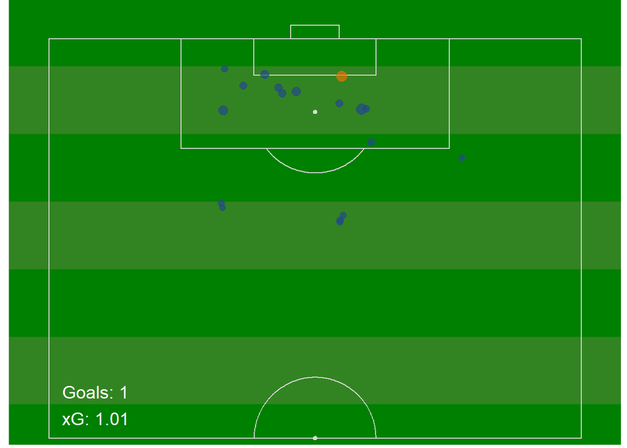

```r
events %>%
  filter(team.name == "United States Women's") %>%
  soccerShotmap(theme = "grass",

                # Fix default pitch size (in meters) to work with StatsBomb coded data
                lengthPitch = 120, widthPitch = 80)
```

**Lab Activity 4**:

1. What information appears to be contained in the above plot?
2. What other information would you like the plot to contain to help you interpret the plot?
3. Can you figure out how to adjust the above code to give you the Netherlands’ goals instead?

Note supposedly this function is able to depict goals from both teams at once (simply comment out the `filter()` line to do so), but it does not appear to plot one team’s goals correctly when I do that. I assume this function requires some debugging to work properly for that purpose, so we’re just doing one team at a time.

Also note the StatsBomb guide has instructions for creating a shot map under Data Use Case 7 (pp. 47-53), but it’s a bit more complicated so I used the `soccermetrics` method for now.

#### xG Accumulation Plot

Let’s now move on to a more complicated task - an xG accumulation plot for a single match. Note this code was modified from [Ryo Nakagarawa’s tutorial here](https://ryo-n7.github.io/2019-08-21-visualize-soccer-statsbomb-part-1/).

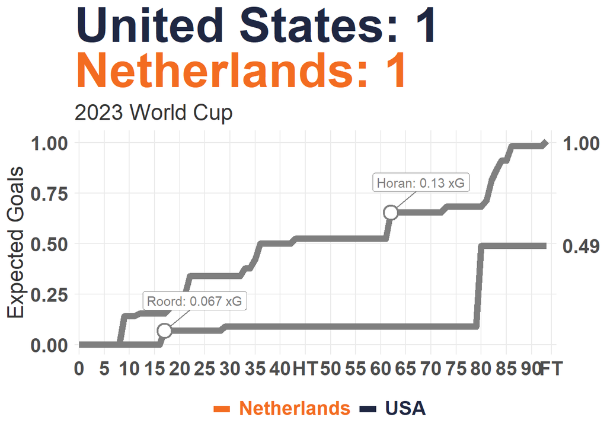

```r
# Create a simple data frame with each team's total xG
events_xg <- events %>%

  # Replace "NA" values with 0 for non-shot events so everything can sum easily
  mutate(shot.statsbomb_xg = replace_na(shot.statsbomb_xg, 0)) %>%

  # For each team, calculate their total xG and round to 2 significant digits
  group_by(team.name) %>%
  summarize(tot_xg = sum(shot.statsbomb_xg) %>% signif(digits = 2)) %>%

  # Create a new column that is just the team name, a colon, the team's total xG, and the characters "xG"
  mutate(team_label = glue("{team.name}: {tot_xg} xG"))



# Create 2 new columns with the team's total xG and team_label in each row
# Note this is clumsy and inefficient, but it's necessary for our plot below
events <- events %>%
  left_join(events_xg, by = "team.name") %>%

  # Create new variable picking just the player's last name as the final "word" in their name column
  mutate(last.name = word(player.name, -1),

         # Create new character string variable for each shot with xG information
         player_label = case_when(shot.outcome.name == "Goal" ~ glue("{last.name}: {shot.statsbomb_xg %>% signif(digits = 2)} xG"),
                                  TRUE ~ ""))



# Create cumulative sum of xG events, if any, organized by each minute for each team
events_rollsum <- events %>%

  # Replace "NA" values with 0 for non-shot events so everything can sum easily
  mutate(shot.statsbomb_xg = replace_na(shot.statsbomb_xg, 0),

         # Mark 1st period extra time as minute 45 to avoid overlap
         minute = case_when(minute >= 45 & period == 1 ~ as.integer(45),
                            TRUE ~ minute)) %>%

  # For each minute, period, and team, total xG from all events (non-shots = 0.0 xG)
  group_by(minute, team.name, period) %>%
  summarize(sumxg = sum(shot.statsbomb_xg)) %>%
  ungroup() %>%

  # For each team, create a new column that is the sum of all previous xG values (i.e. all shots up to that point)
  group_by(team.name) %>%
  mutate(rollsum = lag(cumsum(sumxg)),

         # Replace NAs in first minute with 0
         rollsum = case_when(is.na(rollsum) ~ 0,
                             TRUE ~ rollsum)) %>%

  select(team.name, minute, rollsum, sumxg) %>%

  # Special line to deal with shots in final minute
  mutate(rollsum = case_when(
    row_number() == n() & sumxg != 0 ~ rollsum + sumxg,
    TRUE ~ rollsum
  ))
# Add data on goals to cumulative xG dataset for plot labeling purposes
events_rollsum <- events_rollsum %>%

  # Add data on goal shooter
  left_join(events %>% filter(shot.outcome.name == "Goal") %>% select(minute, shot.outcome.name, team.name, player.name, last.name),
            by = c("minute", "team.name")) %>%

  # Add data on time of goal...
  mutate(minute_goal = minute + 1,

         # ...and total xG after goal as well as label of goal info for plotting purposes
         rollsum_goal = rollsum + sumxg,
         player_label = case_when(shot.outcome.name == "Goal" ~ glue("{last.name}: {sumxg %>% signif(digits = 2)} xG"),
                                  TRUE ~ ""))






# Create small vector of total xG for each team, for plotting purposes
tot_events_df <- events_xg %>%
  pull(tot_xg)



# Create accumulated xG plot and save as events_rollsum_xgplot
# Take events_rollsum dataframe...
events_rollsum_xgplot <- events_rollsum %>%

  # Plot minute on x axis, cumulative sum of xG to that minute on y axis, color lines by team name
  ggplot(aes(x = minute, y = rollsum,
             group = team.name, color = team.name)) +

  # Create lines with thickness 2.5
  geom_line(size = 2.5) +

  # Create labels for each goal
  # Note the data is ONLY the goal events!
  geom_label_repel(data = events_rollsum %>% filter(shot.outcome.name == "Goal"),

                   # Where to place the labels?
                   aes(x = minute_goal, y = rollsum_goal,
                      # What color should they be, and what should they say?
                      color = team.name, label = player_label),

                   # Arguments to help avoid overlap
                   nudge_x = 6, nudge_y = 0.15,

                   # Don't add a legend for these labels
                   show.legend = FALSE) +

  # Create points (circles) for each goal
  # Note the data is ONLY the goal events!
  geom_point(data = events_rollsum %>% filter(shot.outcome.name == "Goal"),
             aes(x = minute_goal, y = rollsum_goal, color = team.name), show.legend = FALSE,
             # Define size and shape of the circles
             size = 5, shape = 21, fill = "white", stroke = 1.25) +

  # Manually set the colors of the chart to be those of the teams (specific red and blue hex color codes)
  scale_color_manual(values = c("Netherlands" = "#F36C21",
                                 "USA" = "#1F2742"),
                     labels = c("<b style ='color:#F36C21'>Netherlands</b>",
                                "<b style='color: #1F2742'>USA</b>")) +
  scale_fill_manual(values = c("Netherlands" = "#F36C21",
                               "USA" = "#1F2742")) +

  # Format the x- and y-axis tick marks, labels, and limits
  scale_x_continuous(breaks = c(seq(0, 90, by = 5), 94),
                     labels = c(seq(0, 40, by = 5), "HT",
                                seq(50, 90, by = 5), "FT"),
                     expand = c(0.01, 0),
                     limits = c(0, 94)) +

  # Create a secondary y-axis (on the right) with only two marks at the total xG values for each team
  scale_y_continuous(sec.axis = sec_axis(~ ., breaks = tot_events_df)) +

  # Give the chart a title, subtitle, and axis labels
  # Note the title here uses CSS formatting, which is something you don't know about yet. Don't worry about it.
  labs(title = "<b style='color: #1F2742'>United States: 1 </b> <br> <b style ='color:#F36C21'>Netherlands: 1 </b>",
       subtitle = "2023 World Cup",
       x = NULL,
       y = "Expected Goals") +

  # Get rid of some extraneous elements
  theme_minimal() +

  # Fiddle with the format of the chart
  theme(plot.title = element_markdown(size = 40),
        plot.subtitle = element_text(size = 18,
                                     color = "grey20"),
        axis.title = element_text(size = 18, color = "grey20"),
        axis.text = element_text(size = 16, face = "bold"),
        panel.grid.minor = element_blank(),
        legend.text = element_markdown(size = 16),
        legend.position = "bottom",
        legend.direction = "horizontal",
        legend.title = element_blank())

# Print plot
events_rollsum_xgplot
```

**Lab Activity 5**:

1. What information is contained in the above plot?
2. Did the “better team” per xG win the game?
3. How could you criticize the above chart?
4. Can you figure out how we might change the above code in order to get the results for a different match?

### Passing Maps

#### Basic Maps

The first thing we’ll do is create a simple passing map for the USA-Netherlands match, based off modified code from pages 22-24 of the StatsBomb Guide.

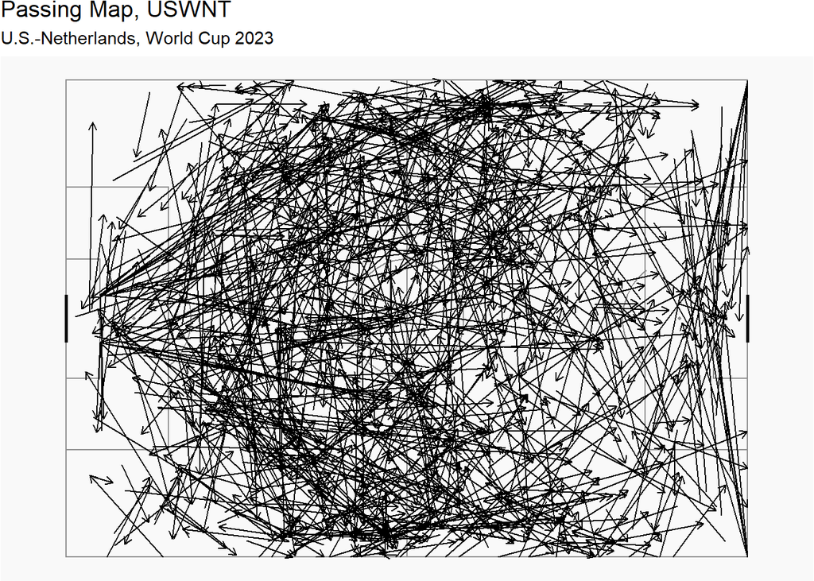

```r
# Take events data, and
passes <- events %>%

  mutate(pass.outcome.name = replace_na(pass.outcome.name, "Complete")) %>%

  # Look at only passes. Could also filter to passes from a specific player, team, pass type, locations, etc.
  filter(type.name=="Pass")


# Create the plot

# Lay down basic pitch
create_Pitch() +

  # Add pass lines
  geom_segment(data = passes,

               # Set start and end positions for the arrows. May also add data by color, line type here
               aes(x = location.x, y = location.y,
                   xend = pass.end_location.x,
                   yend = pass.end_location.y,
                   # color = pass.outcome.name,
                   # color = possession_team.name
                   ),

               # Specify some things about how the arrows should look
               lineend = "round", size = 0.5,
               arrow = arrow(length = unit(0.07, "inches"), ends = "last", type = "open")) +

  # Add title and subtitle
  labs(title = "Passing Map, USWNT", subtitle = "U.S.-Netherlands, World Cup 2023") +

  # Remove any legend titles
  theme(legend.title = element_blank()) +

  # Flip the y-coordinates so the passes plot correctly
  # Always needed - SEE Appendix 2,
  # https://github.com/statsbomb/open-data/blob/master/doc/StatsBomb%20Open%20Data%20Specification%20v1.1.pdf
  scale_y_reverse() +

  # "Fix" the aspect ratio so the pitch doesn't get squished or stretched
  coord_fixed(ratio = 105/100)
```

That’s a pretty basic - and chaotic - passing map.

**Lab Activity 6**:

1. What information can you glean from the above plot?
2. How might you change it? Would you add any information? Subtract it?
3. Try to modify the above code by a.) limiting to only passes into the box; b.) adding code to look at only a specific player; c.) coloring the arrows by outcome; d.) somehow adding information on which team made which pass.
4. After adding information on which team made which pass, what do you notice about how the X-Y coordinate data is stored and oriented?

[figure not shown]

StatsBomb pitch coordinates

```r
passes %>%
  select(possession_team.name, location.x, location.y, pass.end_location.x, pass.end_location.y) %>%
  head(20)
```

```
## # A tibble: 20 x 5
##    possession_team.name  location.x location.y pass.end_location.x pass.end_lo~1
##    <chr>                      <dbl>      <dbl>               <dbl>         <dbl>
##  1 Netherlands Women's         61         40.1                38.5          45
##  2 Netherlands Women's         39.7       47.3               110.           42.5
##  3 United States Women's       14.3       44.7                51.2          77.3
##  4 United States Women's       51.7       77.3                62.6          76.7
##  5 United States Women's       51.8       74.1                59.7          72.7
##  6 Netherlands Women's         67.7        0.1                74.7           6
##  7 United States Women's       50         80                  64.1          74.2
##  8 United States Women's       55.7       69.7                55.9          75.2
##  9 United States Women's       79.8       69.4                73.5          70.6
## 10 United States Women's       66.4       72.7                24.2          57.7
## 11 United States Women's       24.2       57.7                67.7          60.2
## 12 Netherlands Women's         52.1       30.8                44.2          29.7
## 13 Netherlands Women's         44.5       31.1                37.4          20
## 14 Netherlands Women's         41.2       16.1                87.1           9
## 15 Netherlands Women's         33         71.1                58.5          71.6
## 16 Netherlands Women's         61.6        8.5                82.3          31.6
## 17 Netherlands Women's         37.8       48.5                37.8          34.1
## 18 Netherlands Women's         38.2       31.5                40.7          29.4
## 19 Netherlands Women's         70.1       57.4                56.3          63.8
## 20 Netherlands Women's         56.8       64.4                63.6          54
## # ... with abbreviated variable name 1: pass.end_location.y
```

#### Passing Networks

Finally we’re going to do a basic pass network visualization for the USWNT in their match against The Netherlands, once again using the `soccermatics` package.

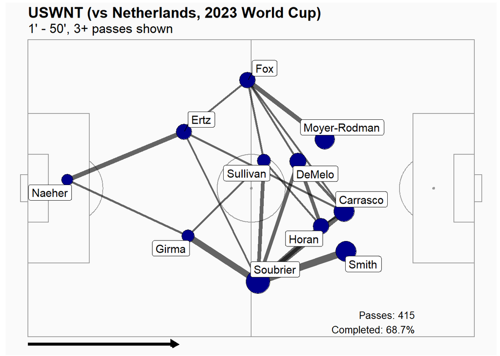

```r
events %>%
  filter(team.name == "United States Women's") %>%
  soccerPassmap(fill = "darkblue", arrow = "r",
                title = "USWNT (vs Netherlands, 2023 World Cup)",
                lengthPitch = 120, widthPitch = 80)
```

**Lab Activity 7**:

1. What do you think the locations of the circles mean? The sizes? The thicknesses of the lines? What are the most common passing pairs? The [What is a Passing Network? section of this blog post](https://statsbomb.com/2018/08/explaining-xgchain-passing-networks/) may help.
2. What information about team structure and strategies can you glean from the above plot?
3. Who is the USWNT’s keeper?

## Other Things You Could Do

The [StatsBomb Guide](https://statsbomb.com/wp-content/uploads/2022/08/Working-with-R.pdf), [this blog post](https://ryo-n7.github.io/2019-08-21-visualize-soccer-statsbomb-part-1/), and the [`soccermatics` package page](https://github.com/JoGall/soccermatics) have some additional easy-to-follow examples for things you can do with this data, including counting goals and shots, xG and xA calculations, maps of defensive actions, and many others ideas.

As noted above, as a next step if you are interested in soccer analytics I strongly encourage you to work through the [StatsBomb 360 Data Case Study from the Men’s EURO 2020](https://statsbomb.com/news/statsbomb-announce-the-release-of-free-statsbomb-360-data-euro-2020-available-now/).

But there are a near-infinite other number of things you could do. Search around on your own, play around with the data, and get your hands dirty!

# Conclusion and Credit

Now you’re well equipped to do some basic soccer analytics in R. Great job!

# Lab HW 4

You will work on this lab with 1-2 partners of your choosing. You should answer these in an RMarkdown document, knit to **PDF** and submit on Canvas. Please turn in a single lab PDF with all your names on it.

**HW Q1**: Create a new passing network graph for a different team and match. It must be for a non-2023 Women’s World Cup match (that is, the data should come from a different “competition” in the free StatsBomb data).

Fill the circles using one of that team’s primary colors.

Then answer the questions from Lab Activity 7, Questions 1-2 for this new chart. Note we may have answered question 1 in class, but I’m looking for you to write up that answer here. (4 pts)

**HW Q2**: Re-create the graphic from Data Use Case 5 in the StatsBomb Guide (pages 29-36). Note the data they start with called `events` is not the same as our `events` above - it’s event data from an entire season, not just one match.

You may use the same data the StatsBomb Guide uses or choose a different league and year.

**In your own words** comment your code to explain what it’s doing. Use the level of detail of comments I provided for the xG Accumulation Plot code above as a guide for what I want to see. The only thing you may have difficulty describing is the `pivot_longer()` function since you’ve never seen it before. My advice is to try and compare the data before to the data after you use `pivot_longer()` and attempt to describe how they’re different. You might also find the [examples at this link](https://tidyr.tidyverse.org/reference/pivot_longer.html#examples) helpful. I will give you some leeway here, though.

Then briefly interpret the plot in 1-2 sentences. (5 pts)

General organization and clarity of the report you turn in is worth 1 pt.